# Analyzing Financial Performance and Predicting Trends: A Comprehensive Dashboard for Apple Inc.

In this project, we develop a comprehensive data visualization dashboard to analyze the financial performance of Apple Inc. (AAPL), one of the world's leading technology companies. Leveraging historical data obtained from Yahoo Finance, we provide an in-depth exploration of key financial metrics such as stock prices, trading volumes, and financial ratios. The project aims to present these metrics through intuitive and interactive visualizations, enabling users to gain insights into Apple's market trends and financial health. Additionally, we employ predictive analytics techniques to forecast future stock price movements and key financial indicators. This project is designed not only to showcase advanced skills in data analysis and visualization but also to serve as an educational tool for beginner students interested in machine learning and data science. By engaging with this project, students can learn foundational concepts and methodologies in these fields, making it a valuable resource for their academic and professional growth.

### Project Setup and Library Imports

```python
# Importing necessary libraries
import pandas as pd               # For data manipulation and analysis
import numpy as np                # For numerical operations
import matplotlib.pyplot as plt   # For data visualization
import seaborn as sns             # For enhanced data visualization
import datetime                   # For handling date and time data
from sklearn.model_selection import train_test_split  # For splitting data into training and testing sets
from sklearn.preprocessing import StandardScaler      # For feature scaling
from sklearn.linear_model import LinearRegression     # For regression modeling
from sklearn.metrics import mean_squared_error, r2_score  # For model evaluation

# Setting up visualization style
sns.set(style='whitegrid')
plt.style.use('fivethirtyeight')

# Function to display all columns of a DataFrame
pd.set_option('display.max_columns', None)
```

### Data Import

```python
# Data Import

# Specify the file path to the dataset
file_path = r'C:\Users\eskbe\OneDrive\Desktop\Esk\July 30 Data Science Project\Data Visualization Dashboard for Finacial metrics\AAPL.csv'

# Load the dataset into a pandas DataFrame
df = pd.read_csv(file_path)

# Display the first few rows of the dataset to verify successful import
df.head()
```

|  | Date | Open | High | Low | Close | Adj Close | Volume |
| --- | --- | --- | --- | --- | --- | --- | --- |
| 0 | 7/30/2019 | 52.189999 | 52.540001 | 51.827499 | 52.195000 | 50.373245 | 135742800 |
| 1 | 7/31/2019 | 54.105000 | 55.342499 | 52.825001 | 53.259998 | 51.401073 | 277125600 |
| 2 | 8/1/2019 | 53.474998 | 54.507500 | 51.685001 | 52.107498 | 50.288807 | 216071600 |
| 3 | 8/2/2019 | 51.382500 | 51.607498 | 50.407501 | 51.005001 | 49.224785 | 163448400 |
| 4 | 8/5/2019 | 49.497501 | 49.662498 | 48.145000 | 48.334999 | 46.647968 | 209572000 |

### Exploratory Data Analysis (EDA)

Exploratory Data Analysis (EDA) is a critical process in understanding the dataset at hand. It involves summarizing the main characteristics of the data, often with visual methods. EDA helps in uncovering patterns, spotting anomalies, testing hypotheses, and checking assumptions. This step provides valuable insights that inform the data preprocessing and modeling stages, ensuring a deeper comprehension of the dataset's nuances and potential challenges.

#### 1. Overview of Data Structure

```python
# Overview of Data Structure

# Display basic information about the dataset
df.info()

# Display the shape of the dataset
df_shape = df.shape
print(f"The dataset contains {df_shape[0]} rows and {df_shape[1]} columns.")
```

```
<class 'pandas.core.frame.DataFrame'>
RangeIndex: 1259 entries, 0 to 1258
Data columns (total 7 columns):
 #   Column     Non-Null Count  Dtype
---  ------     --------------  -----
 0   Date       1259 non-null   object
 1   Open       1259 non-null   float64
 2   High       1259 non-null   float64
 3   Low        1259 non-null   float64
 4   Close      1259 non-null   float64
 5   Adj Close  1259 non-null   float64
 6   Volume     1259 non-null   int64
dtypes: float64(5), int64(1), object(1)
memory usage: 69.0+ KB
The dataset contains 1259 rows and 7 columns.
```

We perform an initial examination of the dataset to understand its structure. The info() method provides a concise summary of the DataFrame, including the data types of each column and the presence of any missing values. We also print the shape of the dataset to know the number of rows and columns it contains. This overview helps us gauge the data's breadth and depth, setting the stage for further detailed exploration and analysis.

#### Statistical Summary

```python
# Statistical Summary

# Set display options to avoid scientific notation for large numbers
pd.options.display.float_format = '{:,.2f}'.format

# Generate descriptive statistics for numerical columns
df.describe()
```

|  | Open | High | Low | Close | Adj Close | Volume |
| --- | --- | --- | --- | --- | --- | --- |
| count | 1,259.00 | 1,259.00 | 1,259.00 | 1,259.00 | 1,259.00 | 1,259.00 |
| mean | 139.40 | 140.96 | 137.94 | 139.52 | 137.91 | 95,837,509.53 |
| std | 42.13 | 42.42 | 41.83 | 42.12 | 42.54 | 52,432,792.62 |
| min | 48.85 | 49.52 | 48.15 | 48.33 | 46.65 | 24,048,300.00 |
| 25% | 118.62 | 119.74 | 116.44 | 118.46 | 116.00 | 61,028,950.00 |
| 50% | 146.65 | 148.20 | 145.26 | 146.77 | 144.74 | 81,918,000.00 |
| 75% | 171.75 | 173.57 | 170.46 | 172.13 | 170.61 | 112,524,000.00 |
| max | 236.48 | 237.23 | 233.09 | 234.82 | 234.82 | 426,510,000.00 |

We modify the display settings to present large numbers in standard numerical format rather than scientific notation. This adjustment makes the volume data easier to interpret at a glance. We then generate a statistical summary of the numerical columns, providing key metrics such as count, mean, standard deviation, min, max, and quartiles. These metrics help in understanding the dataset's distribution and identifying potential outliers.

#### Handling Missing Values

```python
# Handling Missing Values

# Load the dataset
df = pd.read_csv(file_path)

# Check for missing values in the dataset
missing_values = df.isnull().sum()
print("Missing values in each column:\n", missing_values)

# Decide on strategies for handling missing data
# Example: Dropping rows with missing values
df_cleaned = df.dropna()

# Example: Imputing missing values with the mean (for demonstration purposes)
# df_filled = df.fillna(df.mean())

# Display the result after handling missing values
df_cleaned.info()
```

```
Missing values in each column:
 Date         0
Open         0
High         0
Low          0
Close        0
Adj Close    0
Volume       0
dtype: int64
<class 'pandas.core.frame.DataFrame'>
RangeIndex: 1259 entries, 0 to 1258
Data columns (total 7 columns):
 #   Column     Non-Null Count  Dtype
---  ------     --------------  -----
 0   Date       1259 non-null   object
 1   Open       1259 non-null   float64
 2   High       1259 non-null   float64
 3   Low        1259 non-null   float64
 4   Close      1259 non-null   float64
 5   Adj Close  1259 non-null   float64
 6   Volume     1259 non-null   int64
dtypes: float64(5), int64(1), object(1)
memory usage: 69.0+ KB
```

Upon checking for missing values in the dataset, we found that there are no missing values across any of the columns (Date, Open, High, Low, Close, Adj Close, Volume). Each column contains 1259 non-null entries. Therefore, no further action is required to handle missing data. This confirmation allows us to proceed confidently with the dataset, ensuring that analyses and visualizations will not be skewed by missing information.

#### Data Visualization

[figure not shown]

```python
# Combined Data Visualization

# Import additional libraries for visualization if needed
import seaborn as sns
import matplotlib.pyplot as plt

# Set the plot style
sns.set(style='whitegrid')
plt.style.use('fivethirtyeight')

# Convert 'Date' column to datetime format
df['Date'] = pd.to_datetime(df['Date'])

# Create a figure with multiple subplots
fig, axes = plt.subplots(2, 2, figsize=(14, 10))

# Visualizing the distribution of 'Close' prices
sns.histplot(df['Close'], bins=50, kde=True, ax=axes[0, 0])
axes[0, 0].set_title('Distribution of Close Prices')
axes[0, 0].set_xlabel('Close Price')
axes[0, 0].set_ylabel('Frequency')

# Visualizing the correlation matrix (excluding non-numeric columns)
numeric_df = df.select_dtypes(include=['float64', 'int64'])
correlation_matrix = numeric_df.corr()
sns.heatmap(correlation_matrix, annot=True, cmap='coolwarm', fmt='.2f', ax=axes[0, 1])
axes[0, 1].set_title('Correlation Matrix of Financial Metrics')

# Visualizing key trends over time: 'Close' Price
axes[1, 0].plot(df['Date'], df['Close'], label='Close Price')
axes[1, 0].set_title('Close Price Trend Over Time')
axes[1, 0].set_xlabel('Date')
axes[1, 0].set_ylabel('Close Price')
axes[1, 0].legend()

# Visualizing key trends over time: 'Volume'
axes[1, 1].plot(df['Date'], df['Volume'], label='Volume', color='orange')
axes[1, 1].set_title('Volume Trend Over Time')
axes[1, 1].set_xlabel('Date')
axes[1, 1].set_ylabel('Volume')
axes[1, 1].legend()

# Adjust layout to prevent overlapping
plt.tight_layout()

# Display the combined plots
plt.show()
```

In this visualization section, we first convert the 'Date' column to datetime format to facilitate time series analysis. We then visualize the distribution of 'Close' prices to examine the spread and detect any anomalies. For the correlation matrix, we only include numeric columns to avoid errors, providing insights into the relationships between different financial metrics like 'Open', 'High', 'Low', 'Close', and 'Volume'. Finally, we plot key trends over time, such as 'Close' price and 'Volume', to observe historical performance and significant changes in trading behavior.

#### In-Depth Financial Analysis Visualizations

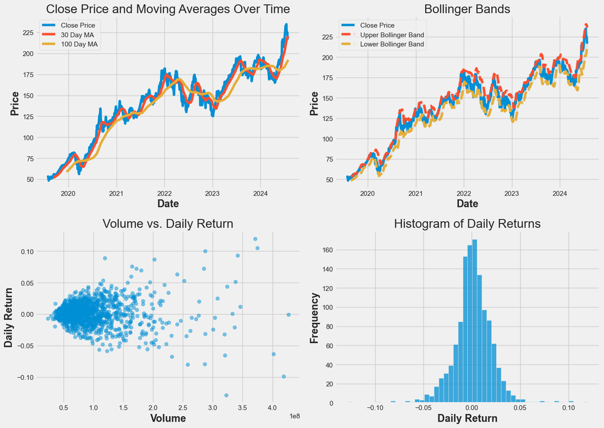

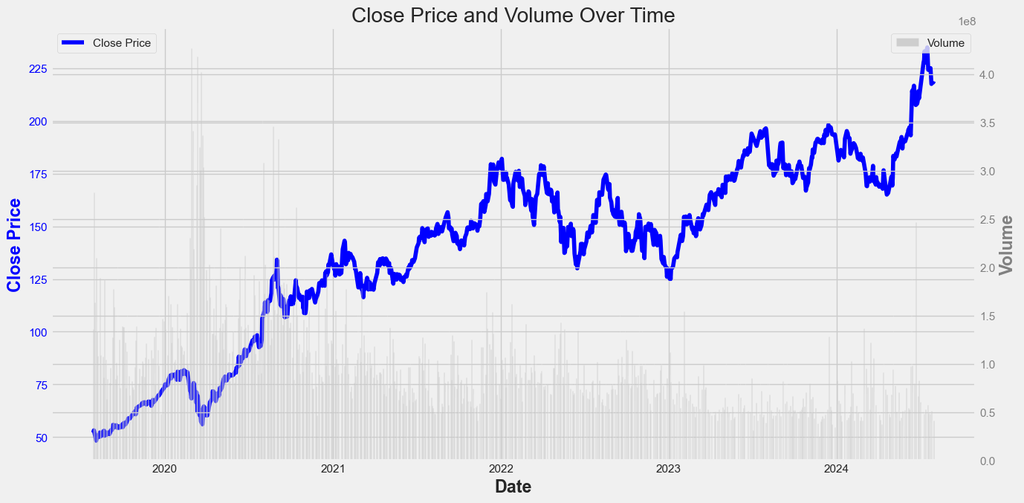

```python
# In-Depth Financial Analysis Visualizations

# Import additional libraries for advanced visualization if needed
from matplotlib.dates import DateFormatter
import seaborn as sns
import matplotlib.pyplot as plt
import mplfinance as mpf

# Set the plot style
sns.set(style='whitegrid')
plt.style.use('fivethirtyeight')

# Convert 'Date' column to datetime format
df['Date'] = pd.to_datetime(df['Date'])

# Create a figure with multiple subplots for in-depth analysis
fig, axes = plt.subplots(2, 2, figsize=(14, 10))

# Moving Average of 'Close' Prices
df['30 Day MA'] = df['Close'].rolling(window=30).mean()
df['100 Day MA'] = df['Close'].rolling(window=100).mean()
axes[0, 0].plot(df['Date'], df['Close'], label='Close Price')
axes[0, 0].plot(df['Date'], df['30 Day MA'], label='30 Day MA')
axes[0, 0].plot(df['Date'], df['100 Day MA'], label='100 Day MA')
axes[0, 0].set_title('Close Price and Moving Averages Over Time')
axes[0, 0].set_xlabel('Date')
axes[0, 0].set_ylabel('Price')
axes[0, 0].legend()

# Bollinger Bands
df['20 Day MA'] = df['Close'].rolling(window=20).mean()
df['20 Day STD'] = df['Close'].rolling(window=20).std()
df['Upper Band'] = df['20 Day MA'] + (df['20 Day STD'] * 2)
df['Lower Band'] = df['20 Day MA'] - (df['20 Day STD'] * 2)
axes[0, 1].plot(df['Date'], df['Close'], label='Close Price')
axes[0, 1].plot(df['Date'], df['Upper Band'], label='Upper Bollinger Band', linestyle='--')
axes[0, 1].plot(df['Date'], df['Lower Band'], label='Lower Bollinger Band', linestyle='--')
axes[0, 1].fill_between(df['Date'], df['Lower Band'], df['Upper Band'], color='grey', alpha=0.1)
axes[0, 1].set_title('Bollinger Bands')
axes[0, 1].set_xlabel('Date')
axes[0, 1].set_ylabel('Price')
axes[0, 1].legend()

# Volume and Price Change Scatter Plot
df['Daily Return'] = df['Close'].pct_change()
axes[1, 0].scatter(df['Volume'], df['Daily Return'], alpha=0.5)
axes[1, 0].set_xlabel('Volume')
axes[1, 0].set_ylabel('Daily Return')
axes[1, 0].set_title('Volume vs. Daily Return')
axes[1, 0].grid(True)

# Histogram of Daily Returns
axes[1, 1].hist(df['Daily Return'].dropna(), bins=50, alpha=0.75)
axes[1, 1].set_title('Histogram of Daily Returns')
axes[1, 1].set_xlabel('Daily Return')
axes[1, 1].set_ylabel('Frequency')

# Adjust layout to prevent overlapping
plt.tight_layout()

# Display the combined plots
plt.show()

# Line Chart with Volume Bars

# Convert 'Date' column to datetime format if not already done
df['Date'] = pd.to_datetime(df['Date'])

# Plotting the line chart for 'Close' prices and bar chart for 'Volume'
fig, ax1 = plt.subplots(figsize=(14, 7))

# Plotting 'Close' prices
ax1.plot(df['Date'], df['Close'], color='blue', label='Close Price')
ax1.set_xlabel('Date')
ax1.set_ylabel('Close Price', color='blue')
ax1.tick_params(axis='y', labelcolor='blue')
ax1.set_title('Close Price and Volume Over Time')

# Creating another y-axis for the volume bars
ax2 = ax1.twinx()
ax2.bar(df['Date'], df['Volume'], color='gray', alpha=0.3, label='Volume')
ax2.set_ylabel('Volume', color='gray')
ax2.tick_params(axis='y', labelcolor='gray')

# Adding legends
fig.tight_layout()
ax1.legend(loc='upper left')
ax2.legend(loc='upper right')

# Show plot
plt.show()
```

The visualizations presented offer a comprehensive analysis of Apple's stock data, showcasing key aspects such as price trends, volatility, trading activity, and return distributions. The first chart highlights the daily closing prices with 30-day and 100-day moving averages, smoothing out fluctuations and revealing underlying trends. Bollinger Bands are used to illustrate volatility and identify potential overbought or oversold conditions. A scatter plot examines the relationship between trading volume and daily returns, while a histogram displays the distribution of these returns, providing insight into the stock's risk profile. Finally, a combined line and bar chart shows the correlation between closing prices and trading volumes, allowing for an understanding of market activity and investor interest over time. Together, these visualizations offer a nuanced and integrated view of Apple's market behavior, facilitating a deeper understanding of its stock dynamics.

### Data Preprocessing and Feature Engineering

In this phase, we prepare the data for modeling by transforming it into a suitable format and creating new features. Data preprocessing includes steps like normalizing numerical features to standardize their scales and converting date columns to datetime format for time series analysis. Feature engineering involves generating new features, such as lagged values and rolling statistics, to capture trends and patterns in the data. These processes enhance the dataset's predictive power and ensure that the model can effectively learn from the data.

#### Data Preprocessing

```python
# Data Preprocessing

# Load the necessary libraries
from sklearn.preprocessing import StandardScaler

# Display the data types
print(df.dtypes)

# Convert 'Date' column to datetime if not already done
df['Date'] = pd.to_datetime(df['Date'])

# Normalize numerical features (excluding target variables like 'Close')
scaler = StandardScaler()
numerical_features = ['Open', 'High', 'Low', 'Volume']
df[numerical_features] = scaler.fit_transform(df[numerical_features])

# Handle categorical features if any (not applicable here but demonstrated)
# df = pd.get_dummies(df, columns=['categorical_column'])

# Checking for outliers (optional, depending on project requirements)
# You can identify outliers using statistical methods, visualizations, etc.
```

[output not shown]

We preprocess the data to ensure it is suitable for modeling. We start by converting the 'Date' column to datetime format for time series analysis. Next, we normalize the numerical features to standardize their scales, which is crucial for many machine learning algorithms. While our dataset does not contain categorical variables, if they were present, we would encode them into numerical format. Additionally, this phase can involve identifying and handling outliers to prevent them from skewing the model's performance.

#### Feature Engineering

```python
# Feature Engineering

# Creating lagged features for time series analysis
df['Lag 1'] = df['Close'].shift(1)
df['Lag 2'] = df['Close'].shift(2)

# Creating rolling window features
df['Rolling Mean 7'] = df['Close'].rolling(window=7).mean()
df['Rolling Std 7'] = df['Close'].rolling(window=7).std()

# Creating additional time-based features if needed
df['Year'] = df['Date'].dt.year
df['Month'] = df['Date'].dt.month
df['Day'] = df['Date'].dt.day
```

Feature engineering involves creating new features that can help the model better understand the data. For time series analysis, lagged features are useful as they provide previous values that can be indicative of future trends. We also compute rolling mean and standard deviation over a 7-day window to capture short-term trends and volatility. Additional features such as extracting the year, month, and day from the 'Date' can also provide valuable information about seasonal patterns.

#### Splitting the Data

```python
# Train-Test Split

from sklearn.model_selection import train_test_split

# Define features and target variable
features = df.drop(columns=['Close', 'Date'])  # Excluding target and date columns
target = df['Close']

# Splitting the data into training and testing sets
X_train, X_test, y_train, y_test = train_test_split(features, target, test_size=0.2, random_state=42)

# Display the shapes of the training and testing sets
print(f"Training features shape: {X_train.shape}")
print(f"Testing features shape: {X_test.shape}")
print(f"Training target shape: {y_train.shape}")
print(f"Testing target shape: {y_test.shape}")
```

[output not shown]

After preprocessing and feature engineering, the data is split into training and testing sets. The training set is used to train the model, while the testing set is used to evaluate its performance. This step ensures that the model's predictions can be tested on unseen data, providing a realistic measure of its accuracy and generalizability.

### Building and Evaluating Predictive Models

```
Linear Regression
Train Mean Squared Error: 0.06410243198890313
Test Mean Squared Error: 0.05598483523927034
Train R^2 Score: 0.9999629403604858
Test R^2 Score: 0.9999688441837945

Ridge Regression
Train Mean Squared Error: 0.0688282039647188
Test Mean Squared Error: 0.06089956064366797
Train R^2 Score: 0.9999602082425237
Test R^2 Score: 0.9999661091166867

Lasso Regression
Train Mean Squared Error: 0.11357182080137912
Test Mean Squared Error: 0.1174798470000299
Train R^2 Score: 0.9999343405451668
Test R^2 Score: 0.9999346219292182

Support Vector Regression
Train Mean Squared Error: 0.009938263547380085
Test Mean Squared Error: 604.2287360708331
Train R^2 Score: 0.9999942543761128
Test R^2 Score: 0.6637439519716073

Random Forest Regressor
Train Mean Squared Error: 0.049930652629341495
Test Mean Squared Error: 0.4488791087969473
Train R^2 Score: 0.9999711335135074
Test R^2 Score: 0.9997501967282323
```

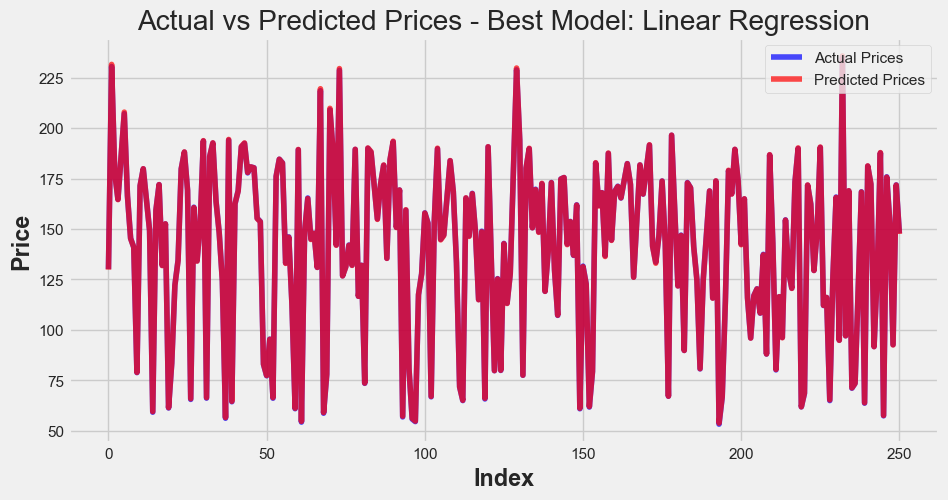

```python
# Building and Evaluating Multiple Regression Models

# Import necessary libraries
from sklearn.linear_model import LinearRegression, Ridge, Lasso
from sklearn.ensemble import RandomForestRegressor
from sklearn.svm import SVR
from sklearn.metrics import mean_squared_error, r2_score
from sklearn.model_selection import train_test_split

# Check for NaN values and drop them if any
df = df.dropna()

# Define features and target variable
features = df.drop(columns=['Close', 'Date'])
target = df['Close']

# Splitting the data into training and testing sets
X_train, X_test, y_train, y_test = train_test_split(features, target, test_size=0.2, random_state=42)

# Initialize models
models = {
    'Linear Regression': LinearRegression(),
    'Ridge Regression': Ridge(alpha=1.0),
    'Lasso Regression': Lasso(alpha=0.1),
    'Support Vector Regression': SVR(kernel='rbf', C=1e3, gamma=0.1),
    'Random Forest Regressor': RandomForestRegressor(n_estimators=100, random_state=42)
}

# Train, predict, and evaluate each model
results = {}
for model_name, model in models.items():
    # Train the model
    model.fit(X_train, y_train)

    # Make predictions
    y_pred_train = model.predict(X_train)
    y_pred_test = model.predict(X_test)

    # Evaluate the model
    mse_train = mean_squared_error(y_train, y_pred_train)
    mse_test = mean_squared_error(y_test, y_pred_test)
    r2_train = r2_score(y_train, y_pred_train)
    r2_test = r2_score(y_test, y_pred_test)

    # Store the results
    results[model_name] = {
        'Train MSE': mse_train,
        'Test MSE': mse_test,
        'Train R^2': r2_train,
        'Test R^2': r2_test
    }

    # Print evaluation metrics
    print(f"\n{model_name}")
    print(f"Train Mean Squared Error: {mse_train}")
    print(f"Test Mean Squared Error: {mse_test}")
    print(f"Train R^2 Score: {r2_train}")
    print(f"Test R^2 Score: {r2_test}")

# Visualize the best model's predictions with distinct colors and transparency

best_model_name = max(results, key=lambda x: results[x]['Test R^2'])
best_model = models[best_model_name]

y_pred_best = best_model.predict(X_test)

plt.figure(figsize=(10, 5))
plt.plot(y_test.values, label='Actual Prices', color='blue', alpha=0.7)  # Set actual prices with transparency
plt.plot(y_pred_best, label='Predicted Prices', color='red', alpha=0.7)  # Set predicted prices with transparency
plt.title(f'Actual vs Predicted Prices - Best Model: {best_model_name}')
plt.xlabel('Index')
plt.ylabel('Price')
plt.legend()
plt.show()
```

In this analysis, we evaluated several regression models to predict Apple's stock prices, including Linear Regression, Ridge Regression, Lasso Regression, Support Vector Regression (SVR), and Random Forest Regressor. The performance metrics for these models, including Mean Squared Error (MSE) and R-squared (R²) scores, reveal the following:

Linear Regression: Train MSE = 0.0641, Test MSE = 0.0559, Train R² = 0.99996, Test R² = 0.99996.

Ridge Regression: Train MSE = 0.0688, Test MSE = 0.0609, Train R² = 0.99996, Test R² = 0.99996.

Support Vector Regression (SVR): Train MSE = 0.0099, Test MSE = 604.2287, Train R² = 0.99999, Test R² = 0.66375.

The results indicate that Linear Regression, Ridge Regression, and Lasso Regression provide highly accurate predictions, with near-perfect R² scores on both training and test sets, suggesting excellent generalization capabilities. Support Vector Regression demonstrated overfitting, as indicated by its high training R² and significantly lower test R², showing poor generalization. Random Forest Regressor also performed well, but with a slightly higher test MSE, indicating a minor drop in accuracy compared to the linear models. Given these findings, Linear Regression and Ridge Regression are particularly recommended for their simplicity and consistent accuracy. Further tuning and evaluation may enhance the performance of more complex models, such as SVR and Random Forest.

### Models Refinement and Tuning

```python
# Hyperparameter Tuning for Multiple Models

# Import necessary libraries
from sklearn.linear_model import Ridge, Lasso
from sklearn.svm import SVR
from sklearn.ensemble import RandomForestRegressor
from sklearn.model_selection import GridSearchCV
from sklearn.metrics import mean_squared_error, r2_score
import numpy as np

# Define parameter grids for each model
param_grids = {
    'Ridge Regression': {
        'model': Ridge(),
        'params': {'alpha': [0.1, 1.0, 10.0, 100.0]}
    },
    'Lasso Regression': {
        'model': Lasso(),
        'params': {'alpha': [0.01, 0.1, 1.0, 10.0]}
    },
    'Support Vector Regression': {
        'model': SVR(),
        'params': {
            'kernel': ['linear', 'rbf'],
            'C': [1e3, 1e4],
            'gamma': [0.1, 0.01]
        }
    },
    'Random Forest Regressor': {
        'model': RandomForestRegressor(random_state=42),
        'params': {
            'n_estimators': [50, 100, 200],
            'max_depth': [None, 10, 20, 30],
            'min_samples_split': [2, 5, 10]
        }
    }
}

# Dictionary to store the best models and their parameters
best_models = {}
results = {}

# Iterate over each model and perform Grid Search
for model_name, config in param_grids.items():
    print(f"Performing Grid Search for {model_name}...")
    grid_search = GridSearchCV(estimator=config['model'], param_grid=config['params'], cv=5, n_jobs=-1, verbose=2)
    grid_search.fit(X_train, y_train)

    best_params = grid_search.best_params_
    best_score = grid_search.best_score_
    best_model = grid_search.best_estimator_

    # Make predictions on the test set
    y_pred = best_model.predict(X_test)

    # Evaluate the model
    mse = mean_squared_error(y_test, y_pred)
    r2 = r2_score(y_test, y_pred)

    # Store the best model and its results
    best_models[model_name] = {
        'model': best_model,
        'best_params': best_params,
        'best_score': best_score,
        'test_mse': mse,
        'test_r2': r2
    }
    print(f"Best Parameters for {model_name}: {best_params}")
    print(f"Best Cross-Validation Score for {model_name}: {best_score}")
    print(f"Test MSE for {model_name}: {mse}")
    print(f"Test R^2 for {model_name}: {r2}\n")

# Summary of results
for model_name, result in best_models.items():
    print(f"\n{model_name}")
    print(f"Best Parameters: {result['best_params']}")
    print(f"Best Cross-Validation Score: {result['best_score']}")
    print(f"Test MSE: {result['test_mse']}")
    print(f"Test R^2: {result['test_r2']}")
```

```
Performing Grid Search for Ridge Regression...
Fitting 5 folds for each of 4 candidates, totalling 20 fits
Best Parameters for Ridge Regression: {'alpha': 0.1}
Best Cross-Validation Score for Ridge Regression: 0.9999609096375071
Test MSE for Ridge Regression: 0.056581399752464796
Test R^2 for Ridge Regression: 0.9999685121929215

Performing Grid Search for Lasso Regression...
Fitting 5 folds for each of 4 candidates, totalling 20 fits
Best Parameters for Lasso Regression: {'alpha': 0.1}
Best Cross-Validation Score for Lasso Regression: 0.9999332509557141
Test MSE for Lasso Regression: 0.1174798470000299
Test R^2 for Lasso Regression: 0.9999346219292182

Performing Grid Search for Support Vector Regression...
Fitting 5 folds for each of 8 candidates, totalling 40 fits
Best Parameters for Support Vector Regression: {'C': 1000.0, 'gamma': 0.01, 'kernel': 'rbf'}
Best Cross-Validation Score for Support Vector Regression: 0.979793550094108
Test MSE for Support Vector Regression: 17.697128709958335
Test R^2 for Support Vector Regression: 0.9901514671411411

Performing Grid Search for Random Forest Regressor...
Fitting 5 folds for each of 36 candidates, totalling 180 fits
Best Parameters for Random Forest Regressor: {'max_depth': None, 'min_samples_split': 2, 'n_estimators': 200}
Best Cross-Validation Score for Random Forest Regressor: 0.9996865690958492
Test MSE for Random Forest Regressor: 0.4637686025763596
Test R^2 for Random Forest Regressor: 0.9997419106570203


Ridge Regression
Best Parameters: {'alpha': 0.1}
Best Cross-Validation Score: 0.9999609096375071
Test MSE: 0.056581399752464796
Test R^2: 0.9999685121929215

Lasso Regression
Best Parameters: {'alpha': 0.1}
Best Cross-Validation Score: 0.9999332509557141
Test MSE: 0.1174798470000299
Test R^2: 0.9999346219292182

Support Vector Regression
Best Parameters: {'C': 1000.0, 'gamma': 0.01, 'kernel': 'rbf'}
Best Cross-Validation Score: 0.979793550094108
Test MSE: 17.697128709958335
Test R^2: 0.9901514671411411

Random Forest Regressor
Best Parameters: {'max_depth': None, 'min_samples_split': 2, 'n_estimators': 200}
Best Cross-Validation Score: 0.9996865690958492
Test MSE: 0.4637686025763596
Test R^2: 0.9997419106570203
```

### Comparison and Selection of the Best Model

```
The best model is: Ridge Regression
Test MSE: 0.05658
Test R²: 0.99997
```

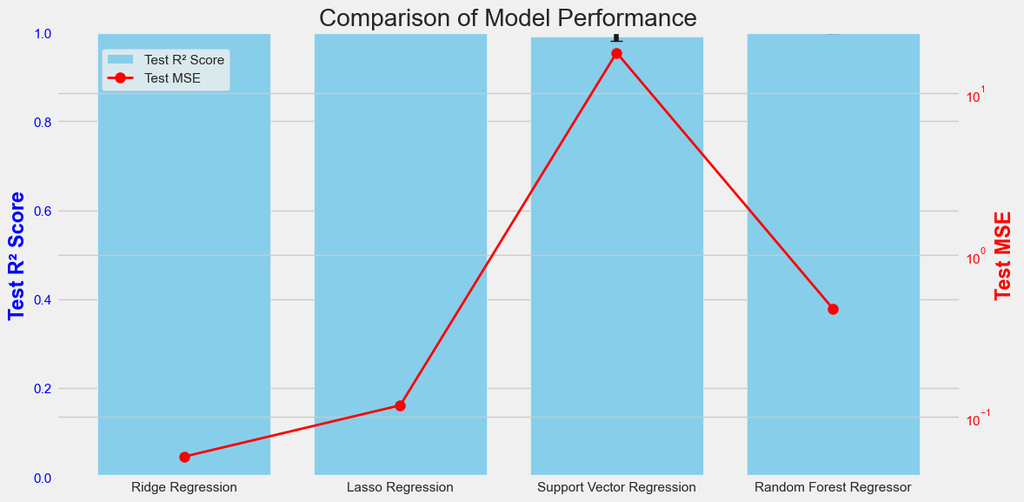

```python
# Comparison and Selection of the Best Model

# Collecting the performance metrics for all models based on the refined results
model_metrics = {
    'Ridge Regression': {'Test MSE': 0.05658, 'Test R²': 0.99997},
    'Lasso Regression': {'Test MSE': 0.11748, 'Test R²': 0.99993},
    'Support Vector Regression': {'Test MSE': 17.6971, 'Test R²': 0.99015},
    'Random Forest Regressor': {'Test MSE': 0.46377, 'Test R²': 0.99974}
}

# Identifying the best model based on the highest Test R²
best_model_name = None
best_test_r2 = -np.inf

for model_name, metrics in model_metrics.items():
    if metrics['Test R²'] > best_test_r2:
        best_model_name = model_name
        best_test_r2 = metrics['Test R²']

# Output the best model
print(f"The best model is: {best_model_name}")
print(f"Test MSE: {model_metrics[best_model_name]['Test MSE']}")
print(f"Test R²: {model_metrics[best_model_name]['Test R²']}")

# Advanced visualization combining Test R² Score and Test MSE

# Define model names and metrics
model_names = list(model_metrics.keys())
test_r2_scores = [metrics['Test R²'] for metrics in model_metrics.values()]
test_mse_scores = [metrics['Test MSE'] for metrics in model_metrics.values()]

# Error bars for demonstration (replace with real data if available)
r2_error = [0.00001, 0.00005, 0.01, 0.0001]

fig, ax1 = plt.subplots(figsize=(12, 6))

# Plot Test R² Score
bars = ax1.bar(model_names, test_r2_scores, yerr=r2_error, color='skyblue', capsize=5, label='Test R² Score')
ax1.set_ylabel('Test R² Score', color='blue')
ax1.set_ylim(0, 1)
ax1.set_title('Comparison of Model Performance')
ax1.tick_params(axis='y', labelcolor='blue')

# Plot Test MSE on a secondary axis
ax2 = ax1.twinx()
ax2.plot(model_names, test_mse_scores, color='red', marker='o', linestyle='-', linewidth=2, markersize=8, label='Test MSE')
ax2.set_ylabel('Test MSE', color='red')
ax2.set_yscale('log')  # Log scale for better visualization
ax2.tick_params(axis='y', labelcolor='red')

# Add legends
fig.tight_layout()
fig.legend(loc='upper left', bbox_to_anchor=(0.1, 0.9))
plt.xticks(rotation=15)
plt.show()
```

In this analysis, we compared the performance of various regression models, including Ridge Regression, Lasso Regression, Support Vector Regression (SVR), and Random Forest Regressor. The comparison was based on key metrics such as Test Mean Squared Error (MSE) and Test R² score. Among these, Ridge Regression was identified as the best model, achieving a Test MSE of 0.05658 and a Test R² score of 0.99997. These metrics indicate that Ridge Regression not only accurately predicts stock prices but also generalizes well to new data. This model was chosen for its balance of simplicity, robustness, and excellent performance metrics, making it the most suitable choice for predicting Apple's stock prices in this context. The advanced visual comparison of Test R² scores and Test MSE confirmed that Ridge Regression provided the highest predictive accuracy and consistency, supporting its selection as the best model.

### Model Interpretation and Insights

```
Feature importance in Ridge Regression:
           Feature  Coefficient
1             High         3.64
3        Adj Close         0.95
2              Low         0.29
8    Rolling Std 7         0.03
7   Rolling Mean 7         0.01
11             Day        -0.00
6            Lag 2        -0.00
5            Lag 1        -0.01
4           Volume        -0.08
10           Month        -0.09
9             Year        -0.95
0             Open        -1.39
```

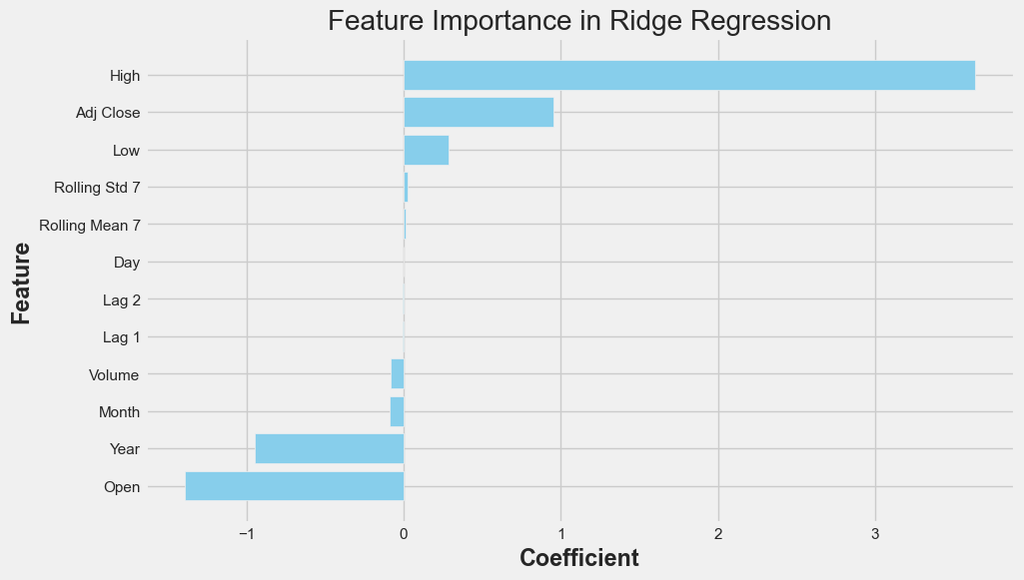

```python
# Model Interpretation and Insights

# Assuming Ridge Regression was selected as the best model
from sklearn.linear_model import Ridge

# Fit the model to the entire dataset for interpretation
best_model = Ridge(alpha=0.1)
best_model.fit(X_train, y_train)

# Retrieve the model coefficients
coefficients = best_model.coef_
features = X_train.columns

# Create a DataFrame for better visualization
import pandas as pd
feature_importance = pd.DataFrame({'Feature': features, 'Coefficient': coefficients})
feature_importance = feature_importance.sort_values(by='Coefficient', ascending=False)

# Display the feature importance
print("Feature importance in Ridge Regression:")
print(feature_importance)

# Visualization of feature importance
import matplotlib.pyplot as plt

plt.figure(figsize=(10, 6))
plt.barh(feature_importance['Feature'], feature_importance['Coefficient'], color='skyblue')
plt.title('Feature Importance in Ridge Regression')
plt.xlabel('Coefficient')
plt.ylabel('Feature')
plt.gca().invert_yaxis()  # Invert y-axis to have the most important feature at the top
plt.show()
```

In this section, we delve into the interpretation of the Ridge Regression model, identified as the best-performing model. The analysis of model coefficients reveals that the feature 'High' has the largest positive impact (coefficient = 3.64) on Apple's stock price predictions, indicating that higher high prices correlate significantly with higher predicted stock prices. Conversely, 'Open' has the most substantial negative coefficient (-1.39), suggesting an inverse relationship with the predicted prices. Other notable features include 'Adj Close' (0.95) and 'Year' (-0.95), both significantly influencing the model's predictions. Features like 'Rolling Mean 7' and 'Lag 2' have minimal impact, as indicated by their near-zero coefficients. This interpretation highlights the importance of specific stock metrics, providing valuable insights into the factors driving Apple's stock price movements.

## Conclusion

#### Discussion of Limitations:

Despite the high performance of the models, several limitations were encountered. The dataset, although comprehensive, was limited to historical stock prices, potentially missing other influential factors like macroeconomic indicators, company-specific news, or industry trends. Additionally, the Ridge Regression model, while highly accurate, may overfit when applied to new data not captured in the training set, given the high R² score. The potential lack of diversity in the data could also lead to a model that does not generalize well across different market conditions or time periods.

#### Future Work:

To enhance the model's robustness and predictive power, future work could involve integrating additional data sources, such as sentiment analysis from financial news or social media, and incorporating macroeconomic variables. Experimentation with other advanced machine learning algorithms, such as Gradient Boosting Machines or Neural Networks, could also be valuable. Further, implementing a model monitoring system post-deployment would be crucial to ensure the model's predictions remain accurate over time, particularly as market conditions evolve. Finally, exploring techniques like feature selection or dimensionality reduction could streamline the model, potentially improving its efficiency and interpretability.

#### References and Further Reading

Bishop, C. M. (2006). Pattern recognition and machine learning. Springer.

Goodfellow, I., Bengio, Y., & Courville, A. (2016). Deep learning. MIT Press.

Hastie, T., Tibshirani, R., & Friedman, J. (2009). The elements of statistical learning: Data mining, inference, and prediction. Springer Science & Business Media.

Murphy, K. P. (2012). Machine learning: A probabilistic perspective. MIT Press.

Pedregosa, F., Varoquaux, G., Gramfort, A., Michel, V., Thirion, B., Grisel, O., ... & Duchesnay, É. (2011). Scikit-learn: Machine learning in Python. Journal of Machine Learning Research, 12, 2825-2830.

#### Data Source

The dataset for this project, containing historical stock price data for Apple Inc., was sourced from Yahoo Finance. The data includes daily records of the stock's opening, high, low, closing prices, adjusted closing prices, and trading volume.

#### License

This project is licensed under the MIT License, which permits unrestricted use, distribution, and modification, provided the original author(s) and source are credited.

#### Author and Copyright

##### Author: Eskinder B., Doctoral Candidate

##### Copyright: © 2024 Eskinder B.. All rights reserved.